# DA5020 - Assignment 9

```r
library(openintro)
library(tidyverse)
```

#### Question 1.1 - (5 pts) Create a scatterplot that illustrates the relationship between the birthweight of babies and the length of their gestational period. Comment on the chart.

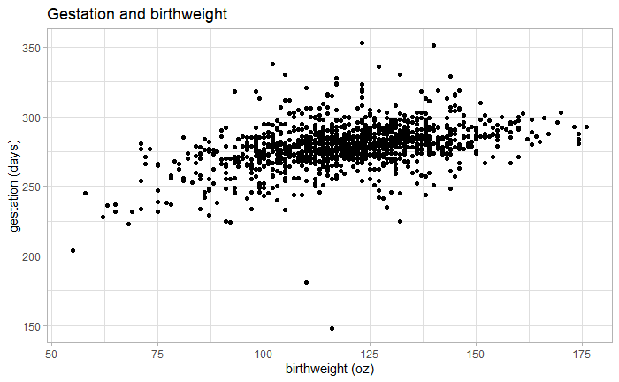

```r
babies %>%
  ggplot(aes(x = bwt,
             y = gestation)) +
  geom_point() +
  labs(title = "Gestation and birthweight",
       x = "birthweight (oz)",
       y = "gestation (days)") +
  theme_light()
```

#### Question 1.2 - (10 pts) Determine if there are outliers in (1) and use a suitable method to programmatically identify them. Note: you are only required to identify the outliers, do not remove them.

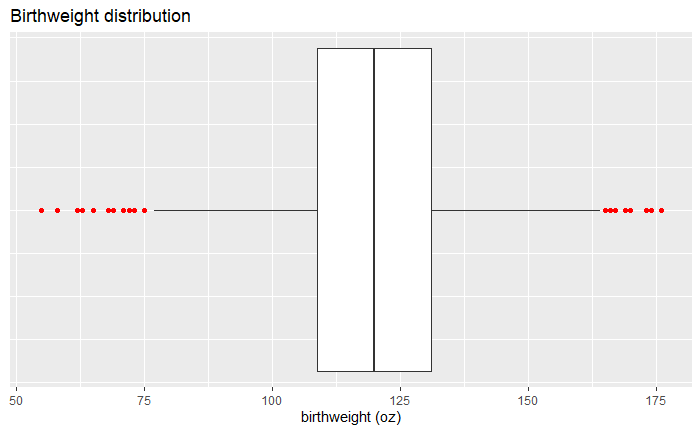

```r
babies %>%
  ggplot(aes(x = bwt)) +
  geom_boxplot(outlier.colour = "red") +
  labs(title = "Birthweight distribution",
       x = "birthweight (oz)") +
  theme(axis.text.y = element_blank(),
        axis.ticks.y = element_blank())
```

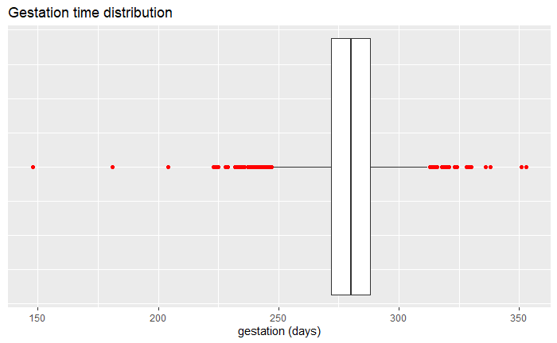

```r
babies %>%
  ggplot(aes(x = gestation)) +
  geom_boxplot(outlier.colour = "red") +
  labs(title = "Gestation time distribution",
       x = "gestation (days)") +
  theme(axis.text.y = element_blank(),
        axis.ticks.y = element_blank())
```

There are outliers in the birthweight data as well as the gestation time data (shown in red.)

#### Question 1.3 - (10 pts) Is there a correlation between the birthweight and the length of the gestational period? Calculate the Pearson coefficient of correlation in R and comment on the strength of the correlation.

```r
babies_na.rm <-
  babies %>%
  select(bwt, gestation) %>%
  drop_na()

cor(babies_na.rm$bwt,
    babies_na.rm$gestation,
    method = "pearson")
```

```
[1] 0.407854
```

#### Question 2.1 - (5 pts) Display a line graph which shows the visitor_count_tho and tourist_spending by the years. Explain any patterns and/or trends.

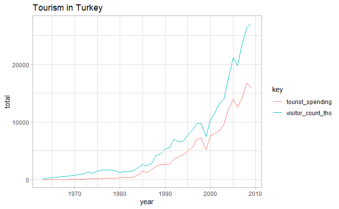

```r
tourism %>%
  pivot_longer(2:3, names_to = "key") %>%
  ggplot(aes(x     = year,
             y     = value,
             color = key)) +
  geom_line() +
  labs(title = "Tourism in Turkey",
       y = "total") +
  theme_light()
```

Visitor count trends proportionally with tourist spending. Dips in the late-90s and mid-2000s likely correspond to civil unrest and government instability during those times due to the 1997 military memorandum and Ergenekon trials, respectively.

#### Question 2.2 - Forecast the tourist_spending for the next time period using: a. (5 pts) a simple moving average of the last four time periods.

```r
## duplicate data
tourism_sma <- tourism

## initialize columns for spending forecast and error
tourism_sma$spending_f <- as.numeric(NA)
tourism_sma$error      <- as.numeric(NA)

## add an entry for the next year
tourism_sma <-
  tourism_sma %>%
  add_row(year = max(tourism_sma$year) + 1)


## forcast spending starting with the fifth record
## in order to have 4 previous values
for (i in seq(5, nrow(tourism_sma))) {
  tourism_sma$spending_f[i] <-
    tourism_sma %>%
    slice((i-1): (i-4)) %>%
    pull(tourist_spending) %>%
    mean()

  ## calculate error
  tourism_sma$error[i] <-
    tourism_sma$tourist_spending[i] -
    tourism_sma$spending_f[i]
}

head(tourism_sma)
```

| year | visitor_count_tho | tourist_spending | spending_f | error |
| --- | --- | --- | --- | --- |
| 1963 | 198 | 7 | NA | NA |
| 1964 | 229 | 8 | NA | NA |
| 1965 | 361 | 13 | NA | NA |
| 1966 | 449 | 12 | NA | NA |
| 1967 | 574 | 13 | 10.0 | 3.0 |
| 1968 | 602 | 24 | 11.5 | 12.5 |

#### Question 2.2 - Forecast the tourist_spending for the next time period using: b. (10 pts) a 3-year weighted moving average of the last three time periods (with weights of 7 for the most recent year, 4 for the one prior and 2 for the one prior to that)

```r
## duplicate data
tourism_wma <- tourism

## initialize columns for spending forecast and error
tourism_wma$spending_f <- as.numeric(NA)
tourism_wma$error      <- as.numeric(NA)

## add an entry for the next year
tourism_wma <-
  tourism_wma %>%
  add_row(year = max(tourism_wma$year) + 1)

## set weights
weights <- c(7, 4, 2)

## forcast spending starting with the fifth record
## in order to have 3 previous values
for (i in seq(4, nrow(tourism_wma))) {
  tourism_wma$spending_f[i] <-
    sum(
      tourism_wma %>%
        slice((i-1): (i-3)) %>%
        pull(tourist_spending) * weights
    ) / sum(weights)

  ## calculate error
  tourism_wma$error[i] <-
    tourism_wma$tourist_spending[i] -
    tourism_wma$spending_f[i]
}

head(tourism_wma)
```

| year | visitor_count_tho | tourist_spending | spending_f | error |
| --- | --- | --- | --- | --- |
| 1963 | 198 | 7 | NA | NA |
| 1964 | 229 | 8 | NA | NA |
| 1965 | 361 | 13 | NA | NA |
| 1966 | 449 | 12 | 10.53846 | 1.461538 |
| 1967 | 574 | 13 | 11.69231 | 1.307692 |
| 1968 | 602 | 24 | 12.69231 | 11.307692 |

```r
## duplicate data
tourism_es <- tourism

## initialize columns for forcast and error
tourism_es$spending_f <- as.numeric(NA)
tourism_es$error      <- as.numeric(NA)

## manually set first forcast and error
tourism_es[1, 4] <- tourism_es[1, 3]
tourism_es[1, 5] <- 0

## add entry for the next year
tourism_es <-
  tourism_es %>%
  add_row(year = max(tourism_es$year) + 1)

## forcast starting from the second entry
for (i in 2:nrow(tourism_es)) {
  tourism_es$spending_f[i] <-
    tourism_es$spending_f[i - 1] +
    0.3*as.numeric(tourism_es$error[i - 1])

  ## calculate error
  tourism_es$error[i] <-
    unlist(tourism_es[i, 3] - tourism_es[i, 4])
}

head(tourism_es)
```

| year | visitor_count_tho | tourist_spending | spending_f | error |
| --- | --- | --- | --- | --- |
| 1963 | 198 | 7 | 7.0000 | 0.0000 |
| 1964 | 229 | 8 | 7.0000 | 1.0000 |
| 1965 | 361 | 13 | 7.3000 | 5.7000 |
| 1966 | 449 | 12 | 9.0100 | 2.9900 |
| 1967 | 574 | 13 | 9.9070 | 3.0930 |
| 1968 | 602 | 24 | 10.8349 | 13.1651 |

#### Question 3 - Calculate the mean squared error for each model in 2.b, and 2.c**

```r
## 2.b - weighted moving average model MSE
tourism_wma$error %>%
  abs() %>%
  na.omit() %>%
  (function(x) sum(x^2)/length(x))
```

```
[1] 1160710
```

```r
## 2.c - exponential smoothing mode MSE
tourism_es$error %>%
  abs() %>%
  na.omit() %>%
  (function(x) sum(x^2)/length(x))
```

```
[1] 2586762
```

The MSE for the weighted moving average model is much lower than the MSE for the exponential smoothing model.

#### Question 4 - (10 pts) Create a suitable visualization of the relationship between visitor_count_tho and tourist_spending. Describe the relationship (in your own words).

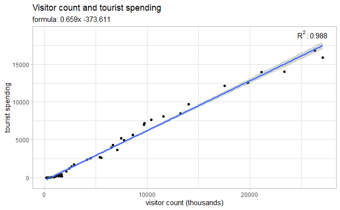

```r
## summarize linear model for quick access to
## useful values
l_model <- summary(
  lm("tourist_spending ~ visitor_count_tho",
     tourism)
)
tourism %>%
  ggplot(aes(x = visitor_count_tho,
             y = tourist_spending)) +
  geom_point() +
  geom_smooth(formula = "y ~ x",
              method  = "lm",
              na.rm   = TRUE) +
  annotate("text",
           x     = max(tourism$visitor_count_tho) - 1000,
           y     = 19000,
           label = parse(
             text = paste0("R^2: ", round(l_model$r.squared, 3)))) +
  labs(title    = "Visitor count and tourist spending",
       subtitle = paste0("formula: ",
                         round(l_model$coefficients[2], 3), "x ",
                         round(l_model$coefficients[1], 3)),
       x        = "visitor count (thousands)",
       y        = "tourist spending") +
  theme_light()
```

Tourist spending is strongly correlated with visitor count. The R-squared value of 0.988 indicates a good fit to a linear regression model and that tourist spending is proportional to visitor count.

#### Question 5 - (15 pts) Build a linear regression model to forecast the tourist_spending based on the visitor_count_tho. Create a chart showing the fitted data, and the linear regression trend line. Make a new prediction and display it in the chart (color-code it in red).

|  | visitor_count_tho | spending_predict |
| --- | --- | --- |
| 1 | 16000 | 10170.92 |
| 2 | 19000 | 12148.02 |
| 3 | 24000 | 15443.19 |

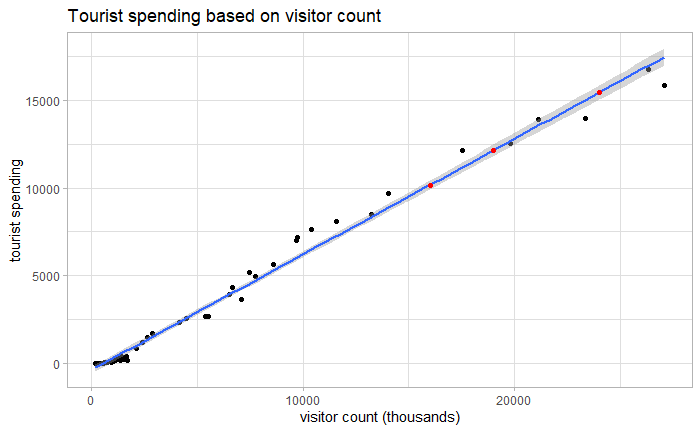

```r
l_model      <- lm("tourist_spending ~ visitor_count_tho",
                   tourism)
predict_spending_fn <- function(x) {
  predict_vals <-
    data.frame("visitor_count_tho" = x)

  predict_vals$spending_predict <-
    predict(l_model, predict_vals)

  plot <- tourism %>%
    ggplot(aes(
      x = visitor_count_tho,
      y = tourist_spending
    )) +
    geom_point() +
    geom_smooth(formula = "y ~ x",
                method  = "lm",
                na.rm   = TRUE) +
    geom_point(data  = predict_vals,
               x     = predict_vals$visitor_count_tho,
               y     = predict_vals$spending_predict,
               color = "red") +
    labs(title = "Tourist spending based on visitor count",
         x     = "visitor count (thousands)",
         y     = "tourist spending") +
    theme_light()

  return(list(
      ## predicted values
      head(predict_vals),

      ## plot
      plot
      ))
}

## predict spending based on input visitor count
predict_spending_fn(c(16000, 19000, 24000))
```

#### Question 6 - (10 pts) Calculate the mean squared error for the model in (5)**. Compare the MSE with the results from (3). Which model is a better estimate of tourist spending? Use the model to determine the forecast for each given time period, then calculate the squared error for each observation and average the squared errors.

```r
## duplicate data
tourism_predicted <- tourism

## predict spending using model
tourism_predicted$spending_predict <-
  predict(l_model, tourism) ## "visitor_count_tho" column is expected

## calculate error
tourism_predicted$error <-
  tourism_predicted$tourist_spending -
  tourism_predicted$spending_predict

head(tourism_predicted)
```

| year | visitor_count_tho | tourist_spending | spending_predict | error |
| --- | --- | --- | --- | --- |
| 1963 | 198 | 7 | -243.122481 | 250.1224806 |
| 1964 | 229 | 8 | -222.692444 | 230.6924439 |
| 1965 | 361 | 13 | -135.700030 | 148.7000296 |
| 1966 | 449 | 12 | -77.705087 | 89.7050868 |
| 1967 | 574 | 13 | 4.674093 | 8.3259066 |
| 1968 | 602 | 24 | 23.127030 | 0.8729703 |

```r
## calculate MSE
tourism_predicted$error %>%
  abs() %>%
  (function(x) sum(x^2)/length(x))
```

```
[1] 280175.6
```

```r
## easier way to calculate MSE
## (errors for linear model stored as "residuals")
l_model[["residuals"]] %>%
  abs() %>%
  (function(x) sum(x^2)/length(x))
```

```
[1] 280175.6
```

The mean squared error for for the linear model is much lower than that of the weighted moving average or exponential smoothing average models, indicating that the linear model is a better estimate of tourist spending.